# MPDW Pertemuan 2

Fedora

2023-09-07

## Pemanggilan *Packages*

```r
library(dplyr)
library(TTR)
library(forecast)
```

```r
library(ggplot2)
library(corrplot)
library(rio) #digunakan untuk import data
library(lmtest) #digunakan untuk uji formal pendeteksian autokorelasi
library(orcutt) #untuk membuat model regresi Cochrane-Orcutt
library(HoRM) #untuk membuat model regresi Hildreth-Lu
library(RColorBrewer)
library(scales)
```

## Input Data

```r
data.wine <- rio::import("https://raw.githubusercontent.com/ffddrraaa/tugas-mk-mpdw/main/Penugasan/Pertemuan%202/Californa%20(Napa)_Wine_Production_1980_2020.csv")

dtWine <- cbind(Price=data.wine$`Price(Dollars/Unit)`, Year=data.wine$Tahun, Harvested=data.wine$HarvestedAcres,Production=data.wine$Production)
Produksi.Wine <- as.data.frame(dtWine)
Produksi.Wine
```

```
##      Price Year Harvested Production
## 1   622.00 2020     22261      80112
## 2   732.00 2019     22152      80155
## 3   773.00 2018     24168      98687
## 4   714.00 2017     25245      89084
## 5   768.00 2016     24831      99996
## 6   772.00 2015     25690     101407
## 7   757.00 2014     27653     113220
## 8   820.00 2013     28970     100180
## 9   982.00 2012     29243      99777
## 10 1157.00 2011     27858     132849
## 11 1229.00 2010     28846     114304
## 12 1260.00 2009     29993     138322
## 13 1240.00 2008     31155     135256
## 14 1205.00 2007     32034     111589
```

[output cut: 27 more lines]

```r
summary(Produksi.Wine)
```

```
##      Price           Year        Harvested       Production
##  Min.   : 622   Min.   :1980   Min.   :22152   Min.   : 80112
##  1st Qu.:1205   1st Qu.:1990   1st Qu.:29243   1st Qu.:102355
##  Median :2464   Median :2000   Median :32365   Median :124000
##  Mean   :2485   Mean   :2000   Mean   :35216   Mean   :127187
##  3rd Qu.:3462   3rd Qu.:2010   3rd Qu.:43031   3rd Qu.:142976
##  Max.   :5862   Max.   :2020   Max.   :45200   Max.   :185000
```

```r
str(Produksi.Wine)
```

```
## 'data.frame':    41 obs. of  4 variables:
##  $ Price     : num  622 732 773 714 768 ...
##  $ Year      : num  2020 2019 2018 2017 2016 ...
##  $ Harvested : num  22261 22152 24168 25245 24831 ...
##  $ Production: num  80112 80155 98687 89084 99996 ...
```

## Eksplorasi Data

```r
#Membentuk objek time series
Price.ts<-ts(Produksi.Wine$Price,frequency = 1, start = 1980, end=2020)
Year<-ts(Produksi.Wine$Year,frequency = 1, start = 1980, end=2020)
Harvested<-ts(Produksi.Wine$Harvested,frequency = 1, start = 1980, end=2020)
Production.ts<-ts(Produksi.Wine$Production,frequency = 1, start = 1980, end=2020)
```

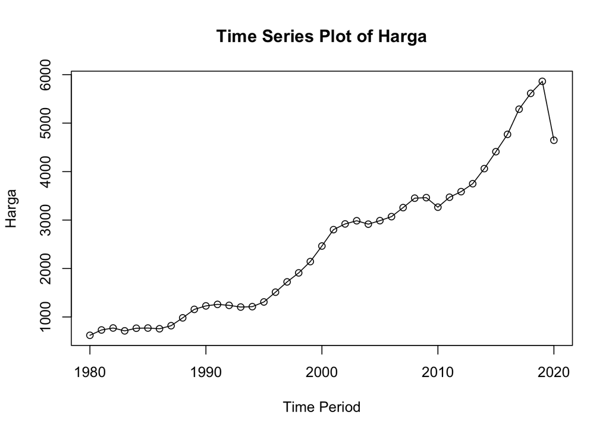

```r
#Eksplorasi Data
#Plot time series
ts.plot(Price.ts, xlab = "Time Period",
        ylab = "Harga",
        main = "Time Series Plot of Harga")
points(Price.ts)
```

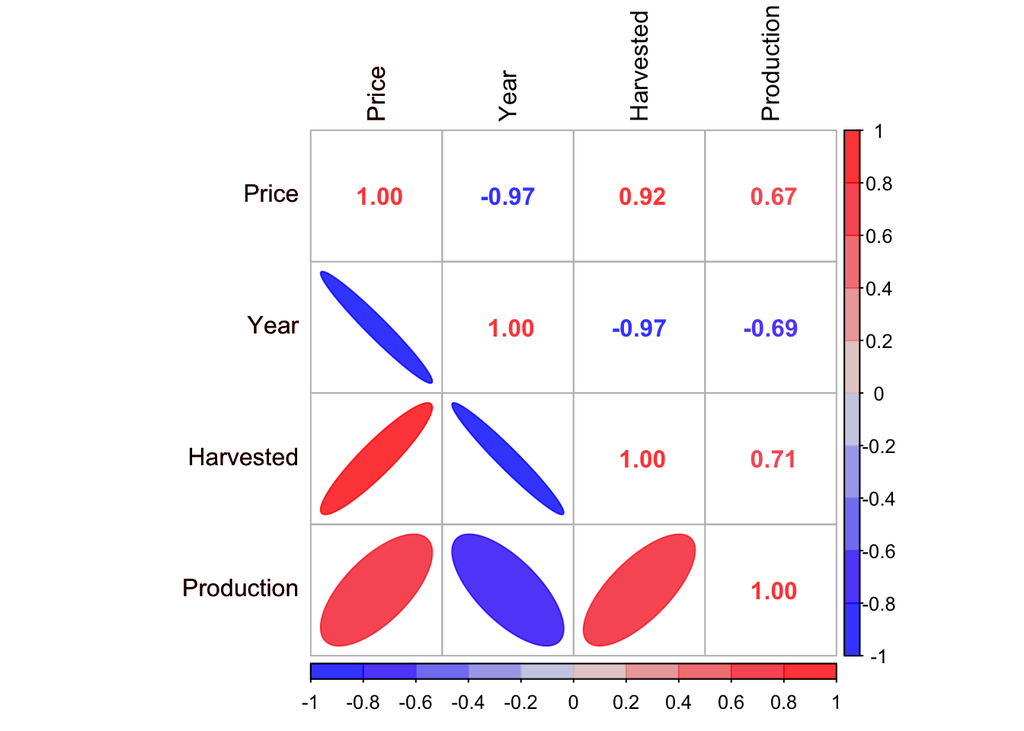

```r
#Menampilkan Nilai Korelasi
m <- cor(Produksi.Wine)

colors <- alpha(colorRampPalette(c("blue", #Warna Bawah
                                   "#dbdbdb", #Warna Tengah
                                   "red"))(10), #Warna Atas
                                   alpha = 0.80) #Transparan

corrplot(m, method = 'ellipse', type='lower', order='original', col=colors)
corrplot(m, add=TRUE, method = 'number', type='upper', order='original',
         tl.pos = "lt",
         tl.col = "black", col=colors)
```

```r
#Pembuatan Model Regresi
#model regresi
model<- lm(Produksi.Wine$Price~Produksi.Wine$Year+Produksi.Wine$Harvested+Produksi.Wine$Production, data = Produksi.Wine)
summary(model)
```

```
##
## Call:
## lm(formula = Produksi.Wine$Price ~ Produksi.Wine$Year + Produksi.Wine$Harvested +
##     Produksi.Wine$Production, data = Produksi.Wine)
##
## Residuals:
##    Min     1Q Median     3Q    Max
## -588.3 -319.9   36.7  209.7  885.7
##
## Coefficients:
##                            Estimate Std. Error t value Pr(>|t|)
## (Intercept)               3.193e+05  4.024e+04   7.934 1.68e-09 ***
## Produksi.Wine$Year       -1.574e+02  1.959e+01  -8.037 1.23e-09 ***
## Produksi.Wine$Harvested  -6.066e-02  3.231e-02  -1.877   0.0684 .
## Produksi.Wine$Production  1.383e-03  3.084e-03   0.449   0.6563
## ---
## Signif. codes:  0 '***' 0.001 '**' 0.01 '*' 0.05 '.' 0.1 ' ' 1
##
## Residual standard error: 382.3 on 37 degrees of freedom
## Multiple R-squared:  0.9417, Adjusted R-squared:  0.937
## F-statistic: 199.4 on 3 and 37 DF,  p-value: < 2.2e-16
```

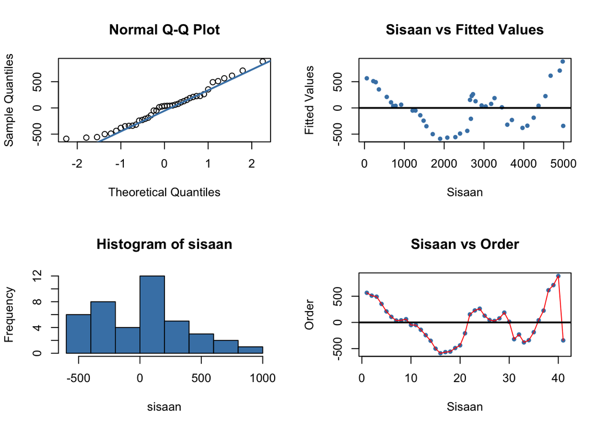

```r
#sisaan dan fitted value
sisaan<- residuals(model)
fitValue<- predict(model)

#Diagnostik dengan eksploratif
par(mfrow = c(2,2))
qqnorm(sisaan)
qqline(sisaan, col = "steelblue", lwd = 2)
plot(fitValue, sisaan, col = "steelblue", pch = 20, xlab = "Sisaan", ylab = "Fitted Values", main = "Sisaan vs Fitted Values")
abline(a = 0, b = 0, lwd = 2)

#Histogram
hist(sisaan, col = "steelblue")

plot(seq(1,41,1), sisaan, col = "steelblue", pch = 20, xlab = "Sisaan", ylab = "Order", main = "Sisaan vs Order")

lines(seq(1,41,1), sisaan, col = "red")
abline(a = 0, b = 0, lwd = 2)
```

Diagram pada samping kiri digunakan untuk melihat apakah sisaan menyebar normal. Pada diagram normal Q-Q plot menunjukkan bahwa sisaan cenderung menyebar normal, tetapi berdasarkan histogram tidak menunjukkan sebaran yang normal. Kemudian dua plot samping kanan menunjukkan apakah model terdapat autokorelasi atau tidak.Plot Sisaan vs *Fitted Value* dan Plot Sisaan vs *Order* menunjukkan adanya pola pada sisaan. Untuk lebih lanjut akan digunakan uji formal melihat normalitas sisaan dan plot ACF dan PACF untuk melihat apakah ada autokorelasi atau tidak.

```r
#Melihat Sisaan Menyebar Normal/Tidak
#H0: sisaan mengikuti sebaran normal
#H1: sisaan tidak mengikuti sebaran normal
shapiro.test(sisaan)
```

```
##
##  Shapiro-Wilk normality test
##
## data:  sisaan
## W = 0.96943, p-value = 0.3303
```

```r
ks.test(sisaan, "pnorm", mean=mean(sisaan), sd=sd(sisaan))
```

```
##
##  Exact one-sample Kolmogorov-Smirnov test
##
## data:  sisaan
## D = 0.076101, p-value = 0.957
## alternative hypothesis: two-sided
```

Berdasarkan uji formal Saphiro-Wilk dan Kolmogorov-Smirnov didapatkan nilai *p-value* > $\alpha$ (5%). Artinya, cukup bukti untuk menyatakan sisaan berdistribusi normal.

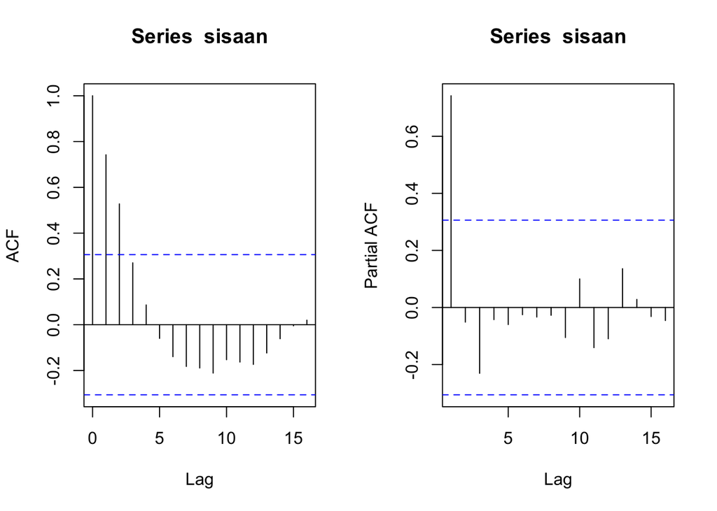

```r
#ACF dan PACF identifikasi autokorelasi
par(mfrow = c(1,2))
acf(sisaan)
pacf(sisaan)
```

```r
#Deteksi autokorelasi dengan uji-Durbin Watson
#H0: tidak ada autokorelasi
#H1: ada autokorelasi
dwtest(model)
```

```
##
##  Durbin-Watson test
##
## data:  model
## DW = 0.43497, p-value = 1.706e-11
## alternative hypothesis: true autocorrelation is greater than 0
```

Berdasarkan hasil DW Test, didapatkan nilai $DW = 0.43497$ dan *p-value* = $1.706e-11$ < alpha 5% dapat disimpulkan bahwa tolak H0, cukup bukti menyatakan terdapat autokorelasi. Berdasarkan tabel Durbin-Watson diperoleh nilai $DL = 1.3480$ dan $DU = 1.6603$ yang artinya terjadi autokorelasi positif.

Oleh karena itu, diperlukan penangan autokorelasi. Penanganan yang akan digunakan menggunakan dua metode, yaitu Cochrane-Orcutt dan Hildret-Lu.

## Penanganan Autokorelasi

### Metode Cochrane-Orcutt

Penanganan metode Cochrane-Orcutt dapat dilakukan dengan bantuan packages Orcutt pada aplikasi `R` maupun secara manual. Berikut ini ditampilkan cara menggunakan bantuan `library` *packages* `Orcutt`.

```r
#Penanganan Autokorelasi Cochrane-Orcutt
modelCO<-cochrane.orcutt(model)
modelCO
```

```
## Cochrane-orcutt estimation for first order autocorrelation
##
## Call:
## lm(formula = Produksi.Wine$Price ~ Produksi.Wine$Year + Produksi.Wine$Harvested +
##     Produksi.Wine$Production, data = Produksi.Wine)
##
##  number of interaction: 7
##  rho 0.760033
##
## Durbin-Watson statistic
## (original):    0.43497 , p-value: 1.706e-11
## (transformed): 1.39374 , p-value: 1.348e-02
##
##  coefficients:
##              (Intercept)       Produksi.Wine$Year  Produksi.Wine$Harvested
##            310078.788675              -153.221794                -0.046368
## Produksi.Wine$Production
##                 0.002966
```

```r
dwtest(modelCO)
```

```
##
##  Durbin-Watson test
##
## data:  modelCO
## DW = 1.3937, p-value = 0.01348
## alternative hypothesis: true autocorrelation is greater than 0
```

Hasil juga menunjukkan bahwa nilai DW dan p-value meningkat menjadi $1.3937$ dan $0.01348$. Namun nilai DW belum masuk dalam rentang DU dan 4-DU. Hal tersebut juga didukung dengan nilai *p-value* < 0.05, artinya bukti menyatakan bahwa sisaan masih terdapat autokorelasi pada taraf nyata 5%.

Untuk nilai $ρ ̂$ optimum yang digunakan adalah $0.760033$. Nilai tersebut dapat diketahui dengan *syntax* berikut.

```r
#Rho optimum
rho<- modelCO$rho
rho
```

```
## [1] 0.7600334
```

```r
#Transformasi Manual
price.trans<- Produksi.Wine$Price[-1]-Produksi.Wine$Price[-41]*rho
Year.trans<- Produksi.Wine$Tahun[-1]-Produksi.Wine$Tahun[-41]*rho
production.trans<- Produksi.Wine$Production[-1]-Produksi.Wine$Production[-41]*rho
Harvested.trans<- Produksi.Wine$Harvested[-1]-Produksi.Wine$Harvested[-41]*rho

modelCOmanual<- lm(Produksi.Wine$Price~Produksi.Wine$Year+Produksi.Wine$Harvested+Produksi.Wine$Production)
summary(modelCOmanual)
```

```
##
## Call:
## lm(formula = Produksi.Wine$Price ~ Produksi.Wine$Year + Produksi.Wine$Harvested +
##     Produksi.Wine$Production)
##
## Residuals:
##    Min     1Q Median     3Q    Max
## -588.3 -319.9   36.7  209.7  885.7
##
## Coefficients:
##                            Estimate Std. Error t value Pr(>|t|)
## (Intercept)               3.193e+05  4.024e+04   7.934 1.68e-09 ***
## Produksi.Wine$Year       -1.574e+02  1.959e+01  -8.037 1.23e-09 ***
## Produksi.Wine$Harvested  -6.066e-02  3.231e-02  -1.877   0.0684 .
## Produksi.Wine$Production  1.383e-03  3.084e-03   0.449   0.6563
## ---
## Signif. codes:  0 '***' 0.001 '**' 0.01 '*' 0.05 '.' 0.1 ' ' 1
##
## Residual standard error: 382.3 on 37 degrees of freedom
## Multiple R-squared:  0.9417, Adjusted R-squared:  0.937
## F-statistic: 199.4 on 3 and 37 DF,  p-value: < 2.2e-16
```

```r
#Mencari Penduga Koefisien Regresi setelah Transformasi ke Persamaan Awal
b0bintang <- modelCOmanual$coefficients[-c(2,3,4)]
b0 <- b0bintang/(1-rho)
b1 <- modelCOmanual$coefficients[-c(1,3,4)]
b2 <- modelCOmanual$coefficients[-c(1,2,4)]
b3 <- modelCOmanual$coefficients[-c(1,2,3)]
b0
```

```
## (Intercept)
##     1330619
```

```r
b1
```

```
## Produksi.Wine$Year
##          -157.4295
```

```r
b2
```

```
## Produksi.Wine$Harvested
##             -0.06065559
```

```r
b3
```

```
## Produksi.Wine$Production
##              0.001383411
```

### Metode Hildreth-Lu

Penanganan kedua adalah menggunakan metode Hildreth-Lu. Metode ini akan mencari nilai SSE terkecil dan dapat dicari secara manual maupun menggunakan packages. Jika menggunakan packages, gunakan `library` *packages* `HORM`.

```r
#Penanganan Autokorelasi Hildreth lu
# Hildreth-Lu
hildreth.lu.func<- function(r, model){
  x1 <- model.matrix(model)[,2]
  x2 <- model.matrix(model)[,3]
  x3 <- model.matrix(model)[,4]
  y <- model.response(model.frame(model))
  n <- length(y)
  t <- 2:n
  y <- y[t]-r*y[t-1]
  x1 <- x1[t]-r*x1[t-1]
  x2 <- x2[t]-r*x2[t-1]
  x3 <- x3[t]-r*x3[t-1]
  return(lm(y~x1+x2+x3))
}

#Pencariab rho yang meminimumkan SSE
r <- c(seq(0.1,0.9, by= 0.1))
tab <- data.frame("rho" = r, "SSE" = sapply(r, function(i){deviance(hildreth.lu.func(i, model))}))
round(tab, 4)
```

```
##   rho     SSE
## 1 0.1 4294356
## 2 0.2 3642466
## 3 0.3 3095359
## 4 0.4 2654079
## 5 0.5 2319454
## 6 0.6 2092143
## 7 0.7 1972753
## 8 0.8 1961854
## 9 0.9 2059694
```

Pertama-tama akan dicari di mana kira-kira $ρ$ yang menghasilkan SSE minimum. Pada hasil di atas terlihat $ρ$ minimum ketika 0.8. Namun, hasil tersebut masih kurang teliti sehingga akan dicari kembali $ρ$ yang lebih optimum dengan ketelitian yang lebih. Jika sebelumnya jarak antar $ρ$ yang dicari adalah 0.1, kali ini jarak antar $ρ$ adalah 0.001 dan dilakukan pada selang 0.6 sampai dengan 0.9.

```r
#Rho optimal
rOpt <- seq(0.6,0.9, by= 0.001)
tabOpt <- data.frame("rho" = rOpt, "SSE" = sapply(rOpt, function(i){deviance(hildreth.lu.func(i, model))}))
head(tabOpt[order(tabOpt$SSE),])
```

```
##       rho     SSE
## 161 0.760 1953165
## 162 0.761 1953171
## 160 0.759 1953171
## 163 0.762 1953187
## 159 0.758 1953188
## 164 0.763 1953213
```

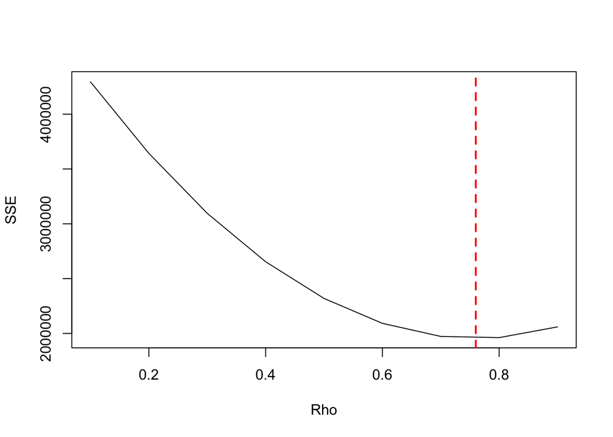

```r
#Grafik SSE optimum
par(mfrow = c(1,1))
plot(tab$SSE ~ tab$rho , type = "l", xlab = "Rho", ylab = "SSE")
abline(v = tabOpt[tabOpt$SSE==min(tabOpt$SSE),"rho"], lty = 2, col="red",lwd=2)
text(x=0.341, y=0.2397500, labels = "rho=0.341", cex = 0.8)
```

Perhitungan yang dilakukan aplikasi `R` menunjukkan bahwa nilai $ρ$ optimum, yaitu saat SSE terkecil terdapat pada nilai $ρ=0.760$. Hal tersebut juga ditunjukkan pada plot. Selanjutnya, model dapat didapatkan dengan mengevaluasi nilai $ρ$ ke dalam fungsi `hildreth.lu.func`, serta dilanjutkan dengan pengujian autokorelasi dengan uji Durbin-Watson. Namun, setelah pengecekan tersebut tidak lupa koefisien regresi tersebut digunakan untuk transformasi balik. Persamaan hasil transformasi itulah yang menjadi persamaan sesungguhnya.

```r
#Model terbaik
modelHL <- hildreth.lu.func(0.760, model)
summary(modelHL)
```

```
##
## Call:
## lm(formula = y ~ x1 + x2 + x3)
##
## Residuals:
##     Min      1Q  Median      3Q     Max
## -928.83 -108.22   31.58  101.80  465.78
##
## Coefficients:
##               Estimate Std. Error t value Pr(>|t|)
## (Intercept)  7.442e+04  1.296e+04   5.742 1.54e-06 ***
## x1          -1.532e+02  2.639e+01  -5.806 1.26e-06 ***
## x2          -4.637e-02  4.046e-02  -1.146   0.2593
## x3           2.966e-03  1.530e-03   1.938   0.0605 .
## ---
## Signif. codes:  0 '***' 0.001 '**' 0.01 '*' 0.05 '.' 0.1 ' ' 1
##
## Residual standard error: 232.9 on 36 degrees of freedom
## Multiple R-squared:  0.7334, Adjusted R-squared:  0.7112
## F-statistic: 33.01 on 3 and 36 DF,  p-value: 1.954e-10
```

```r
#Transformasi Balik
cat("y = ", coef(modelHL)[1]/(1-0.760), "+", coef(modelHL)[2],"x1","+", coef(modelHL)[3],"x2","+",coef(modelHL)[4],"x3", sep = "")
```

```
## y = 310077.5+-153.2211x1+-0.04636841x2+0.002965518x3
```

```r
#Deteksi autokorelasi
dwtest(modelHL)
```

```
##
##  Durbin-Watson test
##
## data:  modelHL
## DW = 1.3937, p-value = 0.01348
## alternative hypothesis: true autocorrelation is greater than 0
```

Hasil uji Durbin-Watson juga menunjukkan bawah nilai DW sebesar $1.3937$ dan tidak berada pada dalam selang daerah tidak ada autokorelasi, yaitu pada rentang DU < DW < 4-DU atau $1.6603 < DW < 2,3397$. Hal tersebut juga didukung oleh *p-value* sebesar $0.01348$, di mana *p-value* < $\alpha$=5%. Artinya tolak $H_0$ atau cukup bukti menyatakan bahwa ada autokorelasi dalam data nilai penjualan wine dengan metode Hildreth-Lu pada taraf nyata 5%.

Terakhir, akan dibandingkan nilai SSE dari ketiga metode (metode awal, metode Cochrane-Orcutt, dan Hildreth-Lu).

```r
#Perbandingan
sseModelawal <- anova(model)$`Sum Sq`[-c(1,2,3)]
sseModelCO <- anova(modelCOmanual)$`Sum Sq`[-c(1,2,3)]
sseModelHL <- anova(modelHL)$`Sum Sq`[-c(1,2,3)]
mseModelawal <- sseModelawal/length(Produksi.Wine$Price)
mseModelCO <- sseModelCO/length(Produksi.Wine$Price)
mseModelHL <- sseModelHL/length(Produksi.Wine$Price)
akurasi <- matrix(c(sseModelawal,sseModelCO,sseModelHL,
                    mseModelawal,mseModelCO,mseModelHL),nrow=2,ncol=3,byrow = T)
colnames(akurasi) <- c("Model Awal", "Model Cochrane-Orcutt", "Model Hildreth-Lu")
row.names(akurasi) <- c("SSE","MSE")
akurasi
```

```
##     Model Awal Model Cochrane-Orcutt Model Hildreth-Lu
## SSE  5408274.0             5408274.0        1953165.48
## MSE   131909.1              131909.1          47638.18
```

Berdasarkan hasil tersebut dapat diketahui bahwa hasil penanganan autokorelasi dengan metode Hildreth-Lu memiliki SSE yang lebih kecil sebesar $1953165.48$ dan lebih baik dibandingkan model awal ketika autokorelasi masih terjadi, yaitu sebesar $5408274.0$.

# Simpulan

Autokorelasi yang terdapat pada dataset wine di kawasan Napa, california tahun 1980-2020 terjadi akibat adanya korelasi di antara unsur penyusunnya.